# Learning Week 8: Role of the pharmacist

PHRM3302 Tutorial

### Learning objectives for the week

*Professions and professionalism*

1. Analyse sociological perspectives on healthcare and healthcare professionals (including pharmacy)
2. Evaluate the role of pharmacy in society and how it changes over time
3. Analyse the concept of pharmaceutical care

*Leadership*

1. Explain the importance of leadership in pharmacists fulfilling their social and professional role
2. Identify the key components of healthcare leadership
3. Reflect on your approach to leadership

### Extend activities

*Professions and professionalism*

- Functions and roles of healthcare
- Perspectives on professions and medical dominance
- Pharmaceutical care (ET)

*Leadership*

- Reflecting on leadership
- Emotional intelligence
- LEADS framework
- (In)effective teams
- Reflection (2) (ET)

### Debate

We are going to debate the following statements:

1. Pharmacist prescribing

   > The regulatory model for pharmacist prescribing should involve pharmacists being trained within and credentialed by [specialist medical colleges](https://www.amc.org.au/accredited-organisations/assessment-and-accreditation-of-specialist-medical-programs/specialist-medical-colleges/)

   Consider: patient outcomes, interprofessional collaborative practice, what it is that makes a profession, medical dominance
2. Pharmaceutical care

   > The social and professional purpose of the pharmacy profession is the provision of clinical care, specifically pharmaceutical care.

   Consider: technical v clinical roles, the definition of pharmaceutical care, whether pharmacists should and/or do take responsibility for patient outcomes

### Process

1. Split into groups of 4–6. Each group further split into Group A (2 to 3 students) and Group B (2 to 3 students).
2. Group A will *affirm* the proposition, Group B will *negate* the proposition.
3. Develop your arguments within your small group (Group A, Group B) 5 minutes
4. Group A presents their arguments to Group B (3 minutes)
5. Group B presents their arguments to Group A (3 minutes)
6. Discuss and develop (if possible) an overall position among the two groups

## Leadership

### Mushing

1. Spend 3 minutes figuring out the key details of mushing. (See [wikipedia](https://en.wikipedia.org/wiki/Mushing#:~:text=Mushing%20is%20a%20sport%20or,a%20rig%20on%20dry%20land.) and this [image](https://en.wikipedia.org/wiki/Mushing#/media/File:Mushing_graphicx.JPG)).

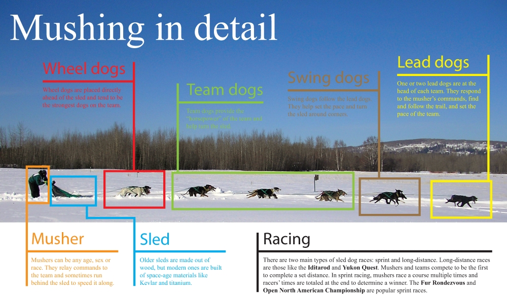

2. Mushers and lead dogs have a unique relationship. Work with your group to identify what you think would be the essential characteristics and behaviours required of dogs that lead the sled.

*You’re wrong about*: [Balto with Blair Braverman](https://app.podscribe.ai/episode/97349606)

Press the play button; 36:00 ~ 40:00 minutes

### Review

1. **Leadership is part of being an effective pharmacist**

   Leadership is not an optional part of practice. You need to demonstrate leadership to be a good practitioner.
2. **Leadership is a set of skills and a mindset**

   Leadership is not about your position, it is about how you approach your role and influence positive outcomes.
3. **Leadership can be learned, and like any complex skill the longer you learn and reflect and improve, the better you will be**

   People aren’t born leaders, they develop their skills often over a considerable period of time.

Discuss these statements. Do you agree? Why/Why not?